# Tipología y ciclo de vida de los datos

## 1.3 Integración y selección de los datos de interés a analizar.

```r
sMat=read.table("data/student-mat.csv",sep=",",header=TRUE)
sPor=read.table("data/student-por.csv",sep=",",header=TRUE)

# Según el propietario de los datos, los alumnos que están presentes en ambas asignaturas
# pueden ser identificados por los siguientes atributos
sBoth=merge(sMat,sPor,by=c("school","sex","age","address","famsize","Pstatus","Medu","Fedu","Mjob","Fjob","reason","nursery","internet"))

# school, sex, age, address, famsize, Pstatus, Medu, Fedu, Mjob, Fjob, reason, nursery, internet
# traveltime, studytime, failures, schoolsup, famsup, paid, activities, higher, romantic, famrel
# freetime, goout, Dalc, Walc, health, absences, subject
```

Ambos ficheros de datos de estudiantes contienen 33 atributos (columnas). El fichero de estudiantes de la asignatura de portugues contiene 649 estudiantes y, el de la asignatura de matemáticas 395 estudiantes. Si mezclamos ambos ficheros para obtener los alumnos que están en ambas asignaturas obtenemos un total de 382 estudiantes.

Identificamos cada estudiante mediante los atributos indicados por el propietario del juego de datos. Generamos un identificador con la concatenación de estos atributos para cada estudiante. Después, en otro paso, convertiremos este identificador en un valor numérico que identifique a cada estudiante.

```r
sMat$id = paste(sMat$school,sMat$sex,sMat$age,sMat$address,sMat$famsize,sMat$Pstatus,sMat$Medu,sMat$Fedu,sMat$Mjob,sMat$Fjob,sMat$reason,sMat$nursery,sMat$internet, sep="-")
sPor$id = paste(sPor$school,sPor$sex,sPor$age,sPor$address,sPor$famsize,sPor$Pstatus,sPor$Medu,sPor$Fedu,sPor$Mjob,sPor$Fjob,sPor$reason,sPor$nursery,sPor$internet, sep="-")
```

Creamos una variable “score” que contendrá la media de las tres notas de los tres trimestres por cada alumno y asignatura. Luego, a partir de esta variable, creamos una variable categórica que exprese si un alumno ha aprobado o suspendido la asignatura.

```r
sMat$score = rowMeans(subset(sMat, select = c(G1, G2, G3)), na.rm = TRUE)
sMat$mark<-sMat$score
sMat$mark[sMat$score<10] <- "fail"
sMat$mark[sMat$score>=10] <- "pass"
sMat$mark <- as.factor(sMat$mark)

sPor$score = rowMeans(subset(sPor, select = c(G1, G2, G3)), na.rm = TRUE)
sPor$mark<-sPor$score
sPor$mark[sPor$score<10] <- "fail"
sPor$mark[sPor$score>=10] <- "pass"
sPor$mark <- as.factor(sPor$mark)
```

Vamos a crear un par de variables binarias nuevas para después unir los dos ficheros en un solo dataset:

```r
sMat$math = 'yes'
sMat$port = 'no'
sPor$math = 'no'
sPor$port = 'yes'
students = rbind(sMat,sPor)
students$port = as.factor(students$port)
students$math = as.factor(students$math)
```

Ahora, a partir del identificador que anteriormente habiamos creado para cada estudiante, lo transformamos en un identificador numérico simple.

```r
students = transform(students, id=as.numeric(factor(id)))
students$id = as.factor(students$id)
```

Ahora tenemos un dataset con 1044 instancias y 38 atributos para un total de 662 estudiantes de ambas asignaturas.

```r
# Resumen
glimpse(students)
```

```
## Observations: 1,044
## Variables: 38
## $ school     <fct> GP, GP, GP, GP, GP, GP, GP, GP, GP, GP, GP, GP, GP,...
## $ sex        <fct> F, F, F, F, F, M, M, F, M, M, F, F, M, M, M, F, F, ...
## $ age        <int> 18, 17, 15, 15, 16, 16, 16, 17, 15, 15, 15, 15, 15,...
## $ address    <fct> U, U, U, U, U, U, U, U, U, U, U, U, U, U, U, U, U, ...
## $ famsize    <fct> GT3, GT3, LE3, GT3, GT3, LE3, LE3, GT3, LE3, GT3, G...
## $ Pstatus    <fct> A, T, T, T, T, T, T, A, A, T, T, T, T, T, A, T, T, ...
## $ Medu       <int> 4, 1, 1, 4, 3, 4, 2, 4, 3, 3, 4, 2, 4, 4, 2, 4, 4, ...
## $ Fedu       <int> 4, 1, 1, 2, 3, 3, 2, 4, 2, 4, 4, 1, 4, 3, 2, 4, 4, ...
## $ Mjob       <fct> at_home, at_home, at_home, health, other, services,...
## $ Fjob       <fct> teacher, other, other, services, other, other, othe...
## $ reason     <fct> course, course, other, home, home, reputation, home...
## $ guardian   <fct> mother, father, mother, mother, father, mother, mot...
## $ traveltime <int> 2, 1, 1, 1, 1, 1, 1, 2, 1, 1, 1, 3, 1, 2, 1, 1, 1, ...
```

[output cut: 25 more lines]

```r
# Estadísticas básicas
summary(students)
```

```
##  school   sex          age        address famsize   Pstatus
##  GP:772   F:591   Min.   :15.00   R:285   GT3:738   A:121
##  MS:272   M:453   1st Qu.:16.00   U:759   LE3:306   T:923
##                   Median :17.00
##                   Mean   :16.73
##                   3rd Qu.:18.00
##                   Max.   :22.00
##
##       Medu            Fedu             Mjob           Fjob
##  Min.   :0.000   Min.   :0.000   at_home :194   at_home : 62
##  1st Qu.:2.000   1st Qu.:1.000   health  : 82   health  : 41
##  Median :3.000   Median :2.000   other   :399   other   :584
##  Mean   :2.603   Mean   :2.388   services:239   services:292
##  3rd Qu.:4.000   3rd Qu.:3.000   teacher :130   teacher : 65
##  Max.   :4.000   Max.   :4.000
##
##         reason      guardian     traveltime      studytime
##  course    :430   father:243   Min.   :1.000   Min.   :1.00
##  home      :258   mother:728   1st Qu.:1.000   1st Qu.:1.00
##  other     :108   other : 73   Median :1.000   Median :2.00
##  reputation:248                Mean   :1.523   Mean   :1.97
##                                3rd Qu.:2.000   3rd Qu.:2.00
##                                Max.   :4.000   Max.   :4.00
##
##     failures      schoolsup famsup     paid     activities nursery
##  Min.   :0.0000   no :925   no :404   no :824   no :528    no :209
##  1st Qu.:0.0000   yes:119   yes:640   yes:220   yes:516    yes:835
##  Median :0.0000
##  Mean   :0.2644
##  3rd Qu.:0.0000
##  Max.   :3.0000
##
##  higher    internet  romantic      famrel         freetime
##  no : 89   no :217   no :673   Min.   :1.000   Min.   :1.000
##  yes:955   yes:827   yes:371   1st Qu.:4.000   1st Qu.:3.000
##                                Median :4.000   Median :3.000
##                                Mean   :3.936   Mean   :3.201
##                                3rd Qu.:5.000   3rd Qu.:4.000
##                                Max.   :5.000   Max.   :5.000
##
```

[output cut: 9 more lines]

```
##  Min.   : 0.000   Min.   : 0.00   Min.   : 0.00   Min.   : 0.00
##  1st Qu.: 0.000   1st Qu.: 9.00   1st Qu.: 9.00   1st Qu.:10.00
##  Median : 2.000   Median :11.00   Median :11.00   Median :11.00
##  Mean   : 4.435   Mean   :11.21   Mean   :11.25   Mean   :11.34
##  3rd Qu.: 6.000   3rd Qu.:13.00   3rd Qu.:13.00   3rd Qu.:14.00
##  Max.   :75.000   Max.   :19.00   Max.   :19.00   Max.   :20.00
##
##        id           score          mark      math      port
##  317    :   4   Min.   : 1.333   fail:321   no :649   no :395
##  326    :   4   1st Qu.: 9.333   pass:723   yes:395   yes:649
##  360    :   4   Median :11.333
##  408    :   4   Mean   :11.267
##  158    :   3   3rd Qu.:13.333
##  185    :   3   Max.   :19.333
##  (Other):1022
```

```r
# Tipo de dato asignado a cada campo
sapply(students, class)
```

```
##     school        sex        age    address    famsize    Pstatus
##   "factor"   "factor"  "integer"   "factor"   "factor"   "factor"
##       Medu       Fedu       Mjob       Fjob     reason   guardian
##  "integer"  "integer"   "factor"   "factor"   "factor"   "factor"
## traveltime  studytime   failures  schoolsup     famsup       paid
##  "integer"  "integer"  "integer"   "factor"   "factor"   "factor"
## activities    nursery     higher   internet   romantic     famrel
##   "factor"   "factor"   "factor"   "factor"   "factor"  "integer"
##   freetime      goout       Dalc       Walc     health   absences
##  "integer"  "integer"  "integer"  "integer"  "integer"  "integer"
##         G1         G2         G3         id      score       mark
##  "integer"  "integer"  "integer"   "factor"  "numeric"   "factor"
##       math       port
##   "factor"   "factor"
```

## 1.4 Limpieza de los datos

¿Los datos contienen ceros o elementos vacíos? ¿Cómo gestionarías cada uno de estos casos?

Identificación y tratamiento de valores extremos.

```r
# Con datos nulos
colSums(is.na(students))
```

```
##     school        sex        age    address    famsize    Pstatus
##          0          0          0          0          0          0
##       Medu       Fedu       Mjob       Fjob     reason   guardian
##          0          0          0          0          0          0
## traveltime  studytime   failures  schoolsup     famsup       paid
##          0          0          0          0          0          0
## activities    nursery     higher   internet   romantic     famrel
##          0          0          0          0          0          0
##   freetime      goout       Dalc       Walc     health   absences
##          0          0          0          0          0          0
##         G1         G2         G3         id      score       mark
##          0          0          0          0          0          0
##       math       port
##          0          0
```

```r
# Con datos ""
colSums(students=="")
```

```
##     school        sex        age    address    famsize    Pstatus
##          0          0          0          0          0          0
##       Medu       Fedu       Mjob       Fjob     reason   guardian
##          0          0          0          0          0          0
## traveltime  studytime   failures  schoolsup     famsup       paid
##          0          0          0          0          0          0
## activities    nursery     higher   internet   romantic     famrel
##          0          0          0          0          0          0
##   freetime      goout       Dalc       Walc     health   absences
##          0          0          0          0          0          0
##         G1         G2         G3         id      score       mark
##          0          0          0          0          0          0
##       math       port
##          0          0
```

```r
# Con datos "?"
colSums(students=="?")
```

```
##     school        sex        age    address    famsize    Pstatus
##          0          0          0          0          0          0
##       Medu       Fedu       Mjob       Fjob     reason   guardian
##          0          0          0          0          0          0
## traveltime  studytime   failures  schoolsup     famsup       paid
##          0          0          0          0          0          0
## activities    nursery     higher   internet   romantic     famrel
##          0          0          0          0          0          0
##   freetime      goout       Dalc       Walc     health   absences
##          0          0          0          0          0          0
##         G1         G2         G3         id      score       mark
##          0          0          0          0          0          0
##       math       port
##          0          0
```

```r
# Valores unicos
apply(students,2, function(x) length(unique(x)))
```

```
##     school        sex        age    address    famsize    Pstatus
##          2          2          8          2          2          2
##       Medu       Fedu       Mjob       Fjob     reason   guardian
##          5          5          5          5          4          3
## traveltime  studytime   failures  schoolsup     famsup       paid
##          4          4          4          2          2          2
## activities    nursery     higher   internet   romantic     famrel
##          2          2          2          2          2          5
##   freetime      goout       Dalc       Walc     health   absences
##          5          5          5          5          5         35
##         G1         G2         G3         id      score       mark
##         18         17         19        662         54          2
##       math       port
##          2          2
```

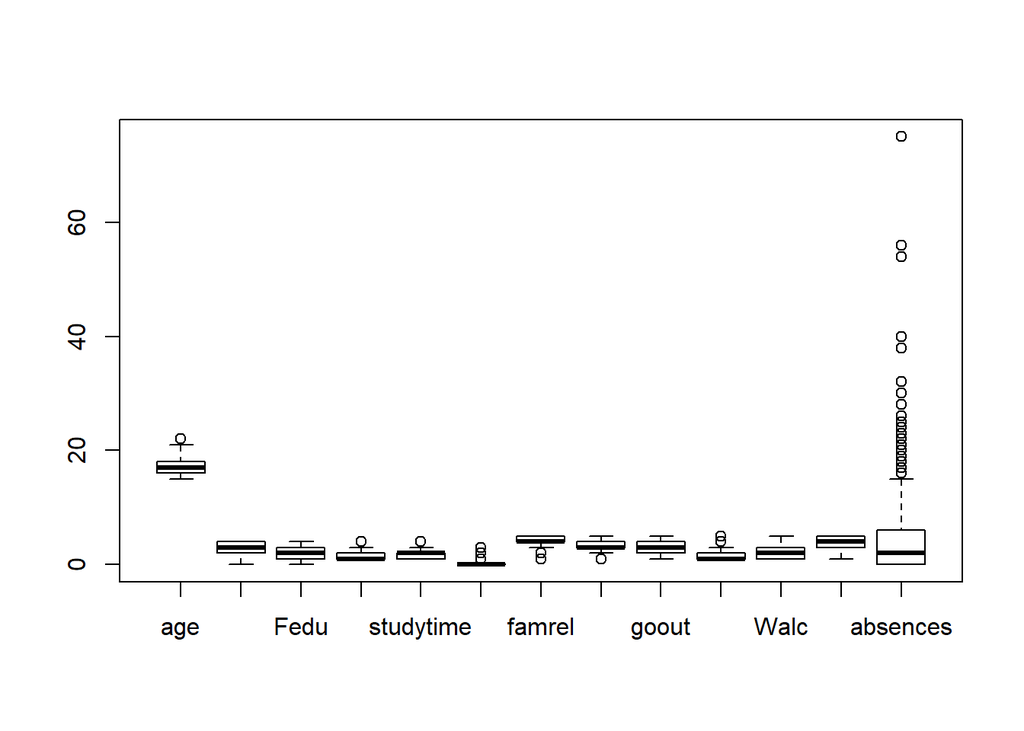

```r
boxplot(students[, c("age", "Medu", "Fedu", "traveltime", "studytime", "failures", "famrel", "freetime", "goout", "Dalc", "Walc", "health", "absences")])
```

```r
# Eliminamos outliers

for(i in 1:ncol(students)) {
  if (is.numeric(students[,i])){
    outliers = boxplot.stats(students[,i])$out
    index = which( students[,i] %in% outliers)
    if(length(index)>0) {
      #students=students[-index,]
    }
  }
}
```

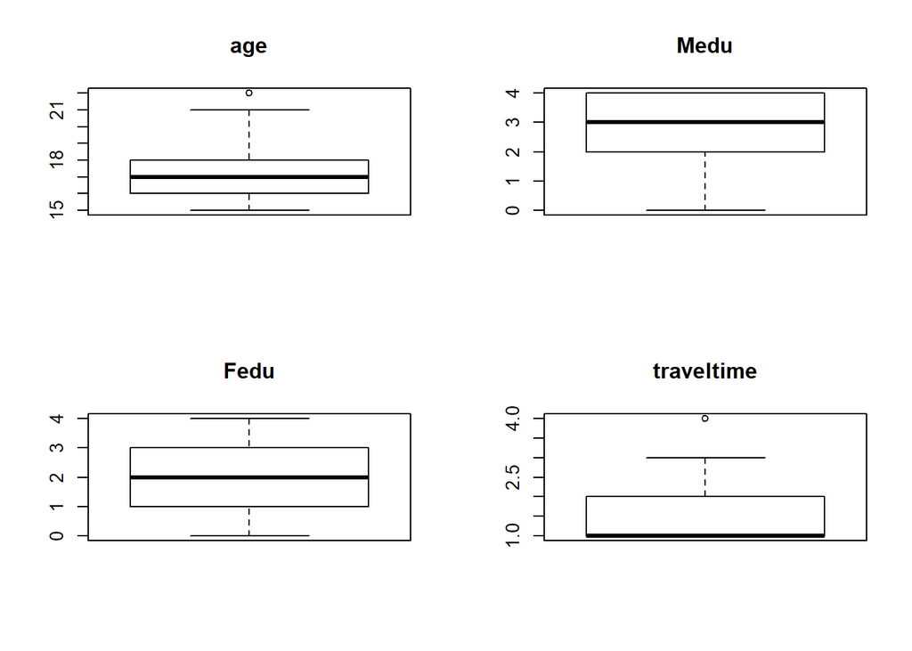

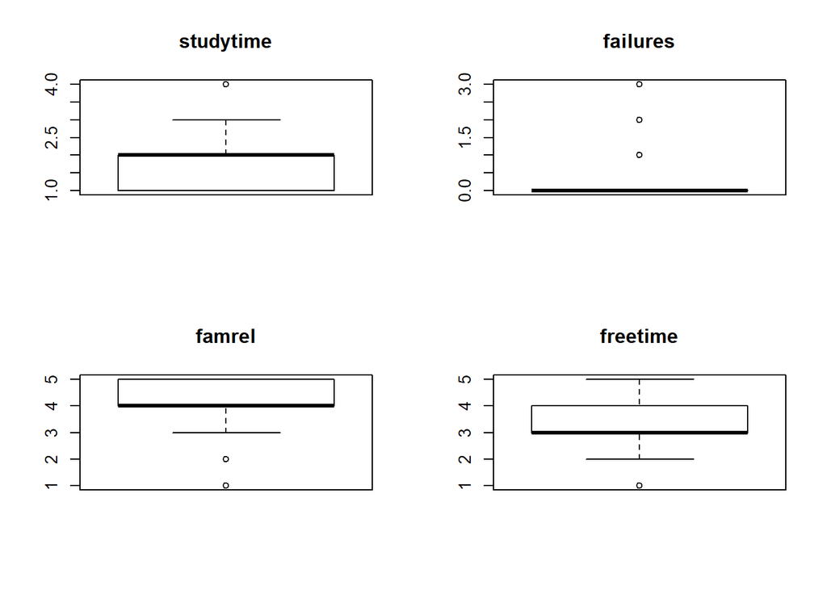

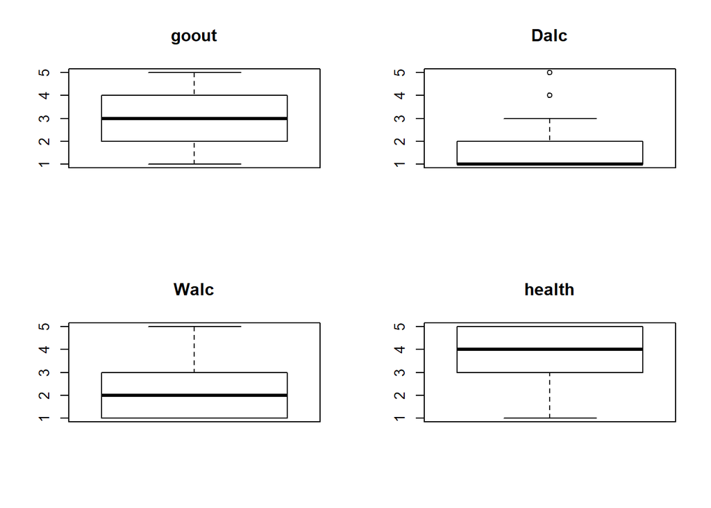

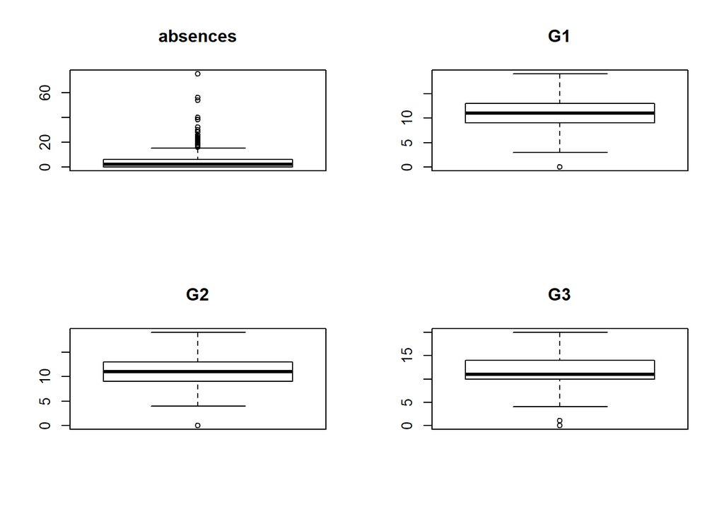

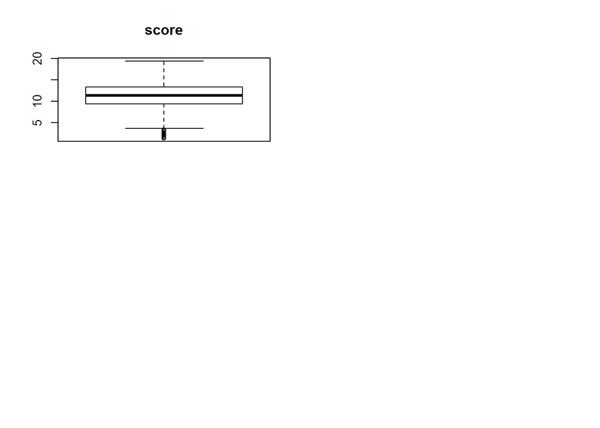

```r
par(mfrow=c(2,2))
for(i in 1:ncol(students)) {
  if (is.numeric(students[,i])){
    boxplot(students[,i], main = colnames(students)[i], width = 100)
  }
}
```

## 1.5 Análisis de los datos

Selección de los grupos de datos que se quieren analizar/comparar (planificación de los análisis a aplicar).

Comprobación de la normalidad y homogeneidad de la varianza.

A continuación, se seleccionan los grupos dentro de nuestro conjunto de datos que pueden resultar interesantes para analizar y/o comparar. No obstante, como se verá en el apartado consistente en la realización de pruebas estadísticas, no todos se utilizarán.

```r
# school, sex, age, address, famsize, Pstatus, Medu, Fedu, Mjob, Fjob, reason, nursery, internet
# traveltime, studytime, failures, schoolsup, famsup, paid, activities, higher, romantic, famrel
# freetime, goout, Dalc, Walc, health, absences, subject

# Agrupación por sexo de los estudiantes
students.male <- students[students$sex == "M",]
students.female <- students[students$sex == "F",]

# Agrupación por si reciben clases particules pagadas o no
students.paid <- students[students$paid == "yes",]
students.nopaid <- students[students$paid == "no",]

# Agrupación por si reciben soporte por parte de la familia
students.famsup <- students[students$famsup == "yes",]
students.nofamsup <- students[students$famsup == "no",]

# Agrupación por si reciben ayuda extra escolar
students.schoolsup <- students[students$schoolsup == "yes",]
students.noschoolsup <- students[students$schoolsup == "no",]

# Agrupación por tiempo dedicado al estudio
students.studytime <- students[students$studytime >= 3,]
students.nostudytime <- students[students$studytime < 3,]

# Agrupación por edad
students.mayores <- students[students$age >= 16,]
students.menores <- students[students$age < 16,]

# Agrupación por asignatura
students.port <- students[students$port == "yes",]
students.math <- students[students$math == "yes",]
```

### 1.5.1 Análisis visual

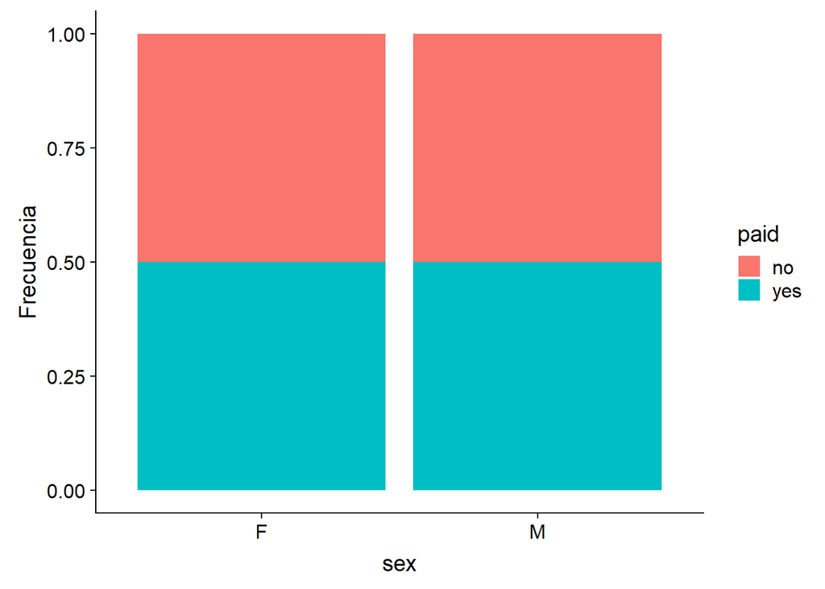

```r
ggplot(data = students[1:length(students),],aes(x=sex,fill=paid))+geom_bar(position="fill")+ylab("Frecuencia")
```

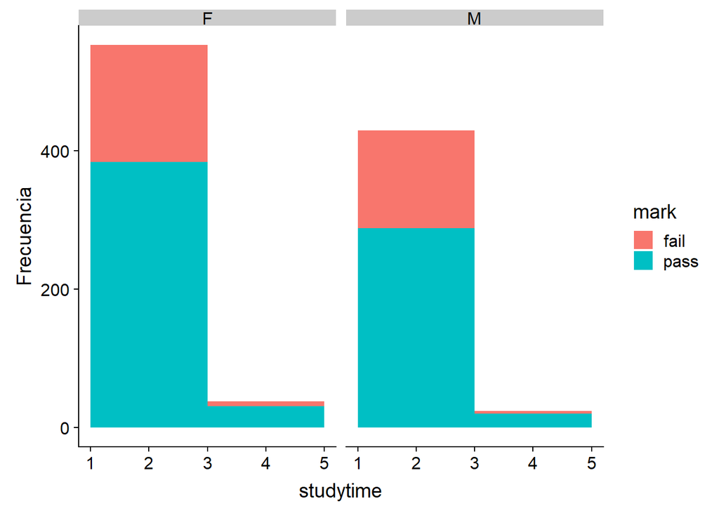

```r
ggplot(students,aes(x=studytime,fill=mark))+geom_histogram(binwidth = 2)+ylab("Frecuencia")+facet_wrap(~sex )
```

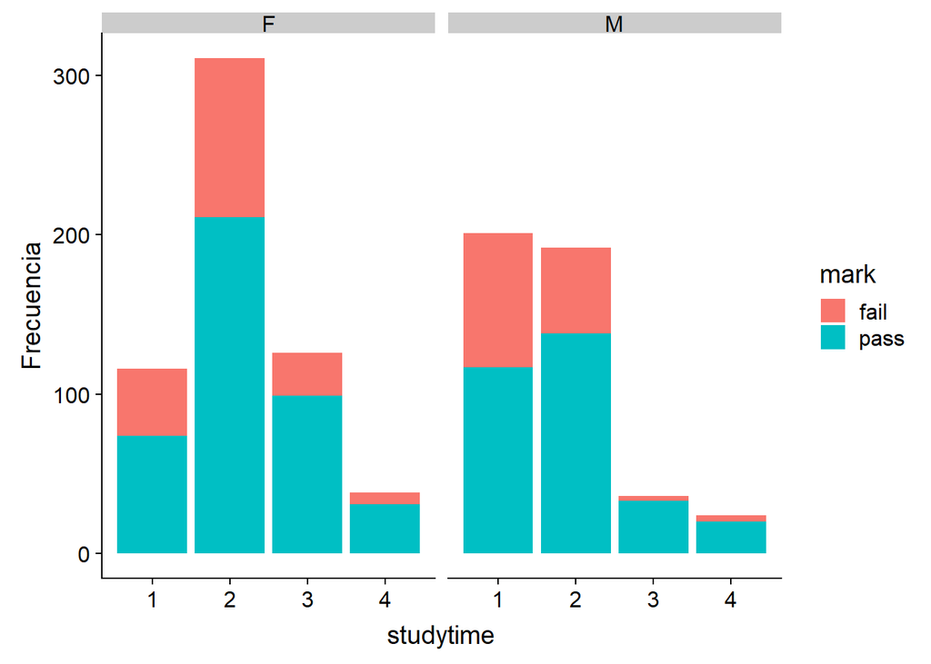

```r
ggplot(students,aes(x=studytime,fill=mark))+geom_bar()+ylab("Frecuencia")+facet_wrap(~sex )
```

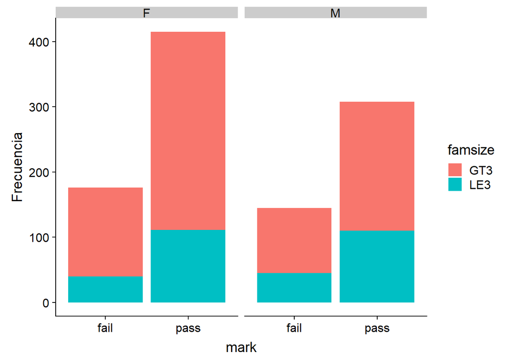

```r
ggplot(students,aes(x=mark,fill=famsize))+geom_bar()+ylab("Frecuencia")+facet_wrap(~sex )
```

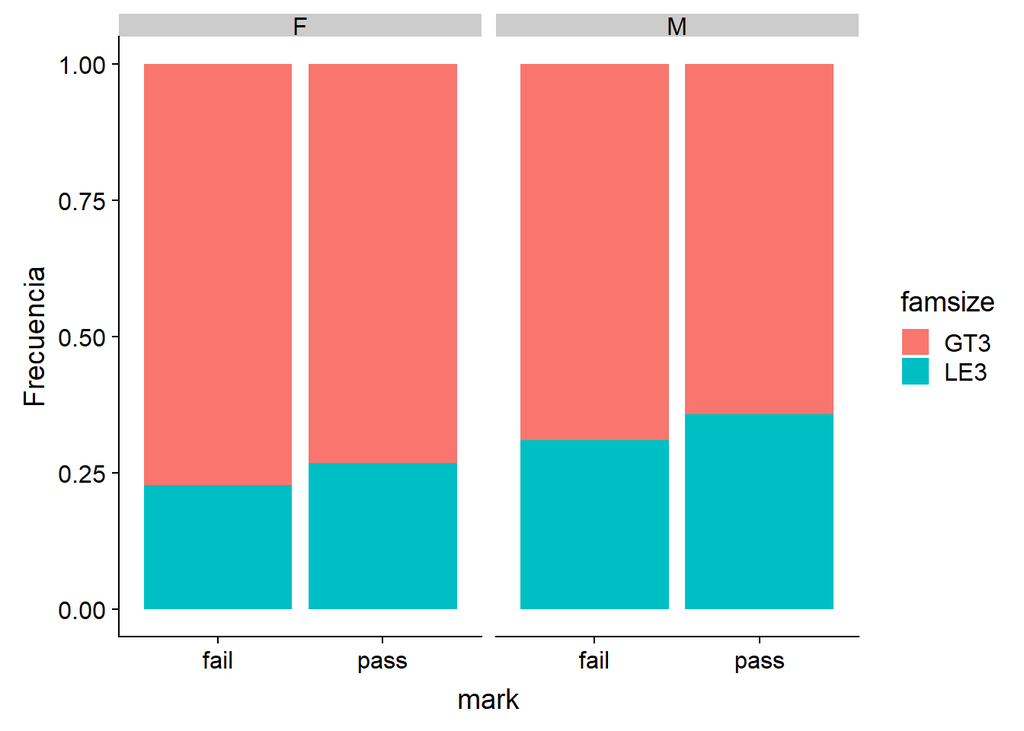

```r
ggplot(students,aes(x=mark,fill=famsize))+geom_bar(position='fill')+ylab("Frecuencia")+facet_wrap(~sex )
```

```r
# Tests de normalidad
library(nortest)

# Función que aplica distintos test de homogeneidad sobre los datos de entrada
normTest <- function(data, name) {
  ad_val = (ad.test(data)$p.value > alpha) # Anderson-Darling test
  ks_val = (ks.test(data, pnorm, mean(data), sd(data))$p.value > alpha) # Kolmogorov-Smirnov test
  sh_val = (shapiro.test(data)$p.value > alpha) # Shapiro test
  cat(name)
  cat("\t")
  cat(ad_val,ks_val,sh_val,"\t")
  cat("\n")
}

alpha = 0.05
col.names = colnames(students)
cat("Distribucion normal: \n")
```

```
## Distribucion normal:
```

```r
for (i in 1:ncol(students)) {
  if (is.integer(students[,i]) | is.numeric(students[,i])) {
    normTest(students[,i], col.names[i])
  }
}
```

```
## age  FALSE FALSE FALSE
## Medu FALSE FALSE FALSE
## Fedu FALSE FALSE FALSE
## traveltime   FALSE FALSE FALSE
## studytime    FALSE FALSE FALSE
## failures FALSE FALSE FALSE
## famrel   FALSE FALSE FALSE
## freetime FALSE FALSE FALSE
## goout    FALSE FALSE FALSE
## Dalc FALSE FALSE FALSE
## Walc FALSE FALSE FALSE
## health   FALSE FALSE FALSE
## absences FALSE FALSE FALSE
## G1   FALSE FALSE FALSE
## G2   FALSE FALSE FALSE
## G3   FALSE FALSE FALSE
## score    FALSE FALSE FALSE
```

```r
normTest(students.female[,c("goout")], "goout~female")
```

```
## goout~female FALSE FALSE FALSE
```

```r
normTest(students.male[,c("goout")], "goout~male")
```

```
## goout~male   FALSE FALSE FALSE
```

```r
normTest(students.female[,c("Walc")], "Walc~female")
```

```
## Walc~female  FALSE FALSE FALSE
```

```r
normTest(students.male[,c("Walc")], "Walc~male")
```

```
## Walc~male    FALSE FALSE FALSE
```

```r
normTest(students.female[,c("score")], "score~female")
```

```
## score~female FALSE TRUE FALSE
```

```r
normTest(students.male[,c("score")], "score~male")
```

```
## score~male   FALSE FALSE FALSE
```

```r
normTest(students.studytime[,c("score")], "score~studytime")
```

```
## score~studytime  TRUE TRUE FALSE
```

```r
normTest(students.nostudytime[,c("score")], "score~nostudytime")
```

```
## score~nostudytime    FALSE FALSE FALSE
```

```r
normTest(students.mayores[,c("score")], "score~mayores")
```

```
## score~mayores    FALSE FALSE FALSE
```

```r
normTest(students.menores[,c("score")], "score~menores")
```

```
## score~menores    TRUE TRUE TRUE
```

```r
normTest(students.paid[,c("score")], "score~paid")
```

```
## score~paid   TRUE TRUE TRUE
```

```r
normTest(students.nopaid[,c("score")], "score~nopaid")
```

```
## score~nopaid FALSE FALSE FALSE
```

```r
normTest(students.schoolsup[,c("score")], "score~schoolsup")
```

```
## score~schoolsup  TRUE TRUE TRUE
```

```r
normTest(students.noschoolsup[,c("score")], "score~noschoolsup")
```

```
## score~noschoolsup    FALSE FALSE FALSE
```

```r
normTest(students.famsup[,c("score")], "score~famsup")
```

```
## score~famsup FALSE TRUE FALSE
```

```r
normTest(students.nofamsup[,c("score")], "score~nofamsup")
```

```
## score~nofamsup   FALSE TRUE FALSE
```

```r
fligner.test(score ~ age, data = students)
```

```
##
##  Fligner-Killeen test of homogeneity of variances
##
## data:  score by age
## Fligner-Killeen:med chi-squared = 23.529, df = 7, p-value =
## 0.001378
```

```r
fligner.test(score ~ sex, data = students)
```

```
##
##  Fligner-Killeen test of homogeneity of variances
##
## data:  score by sex
## Fligner-Killeen:med chi-squared = 0.19607, df = 1, p-value =
## 0.6579
```

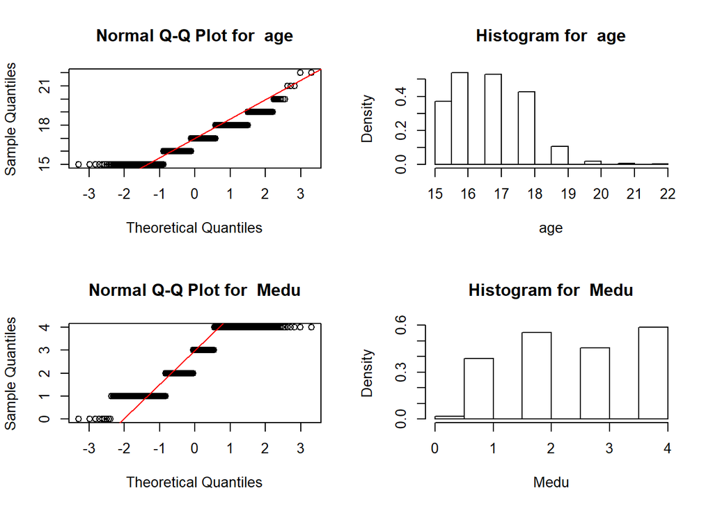

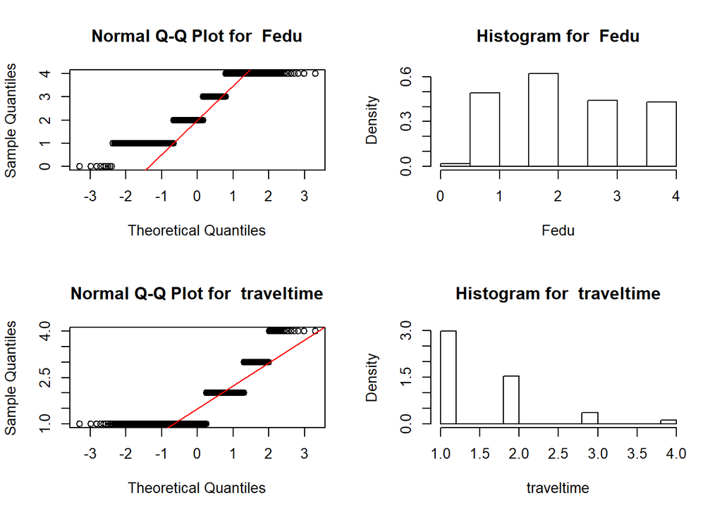

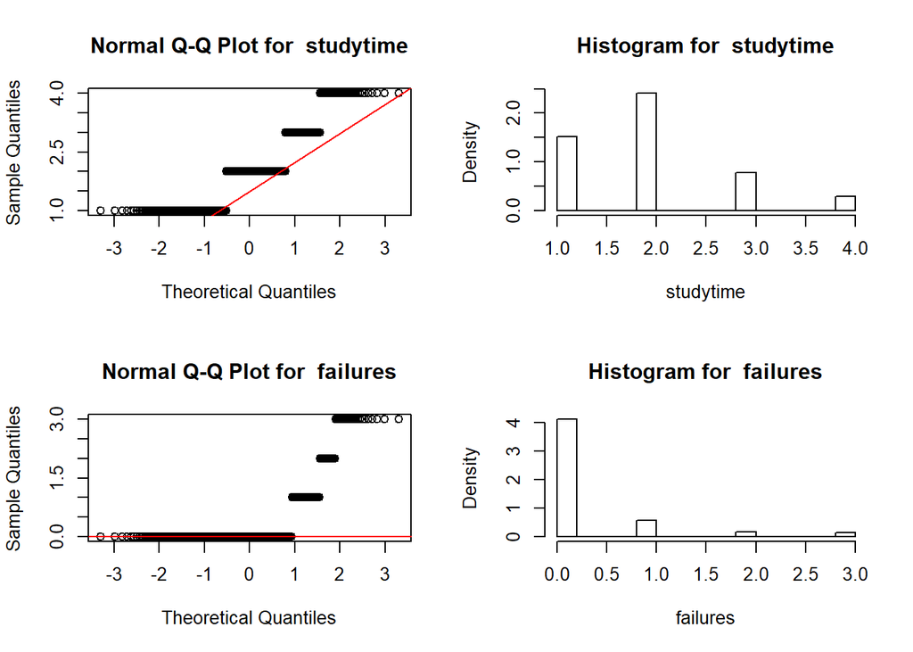

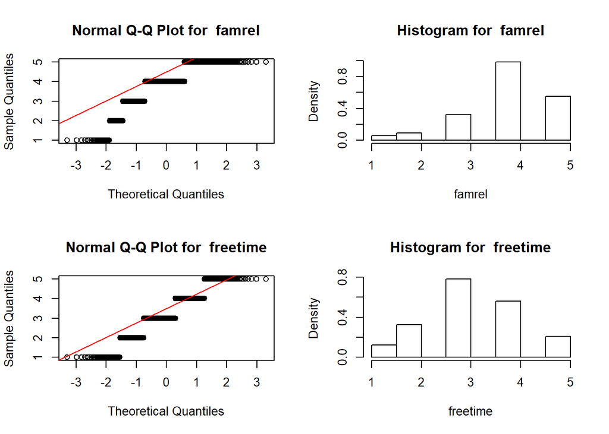

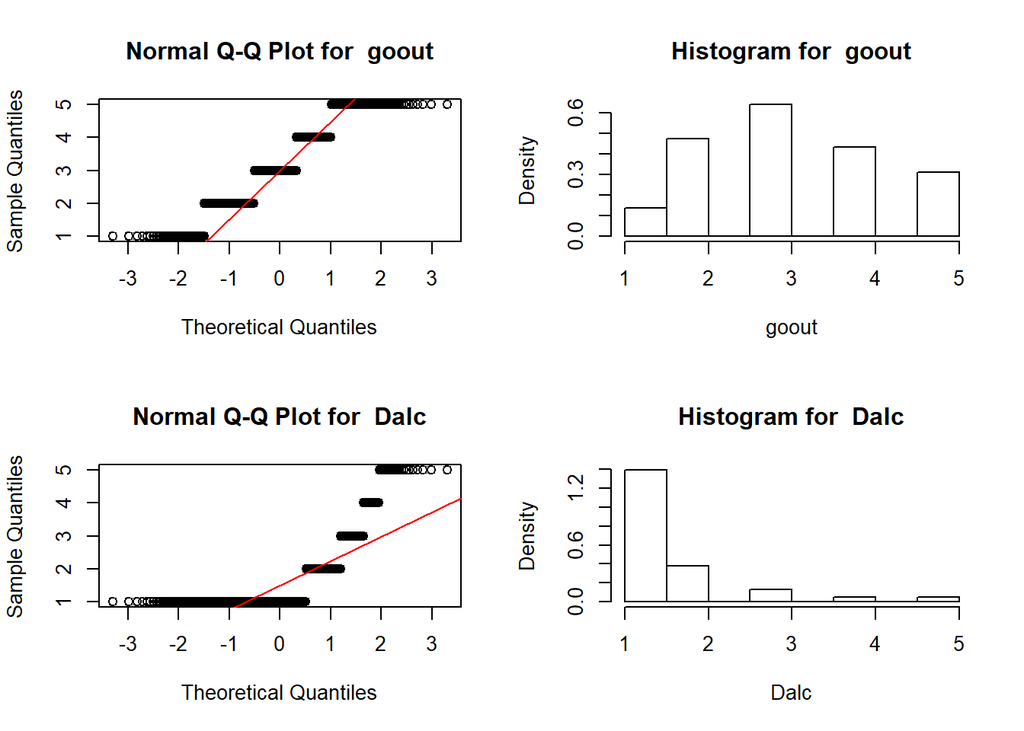

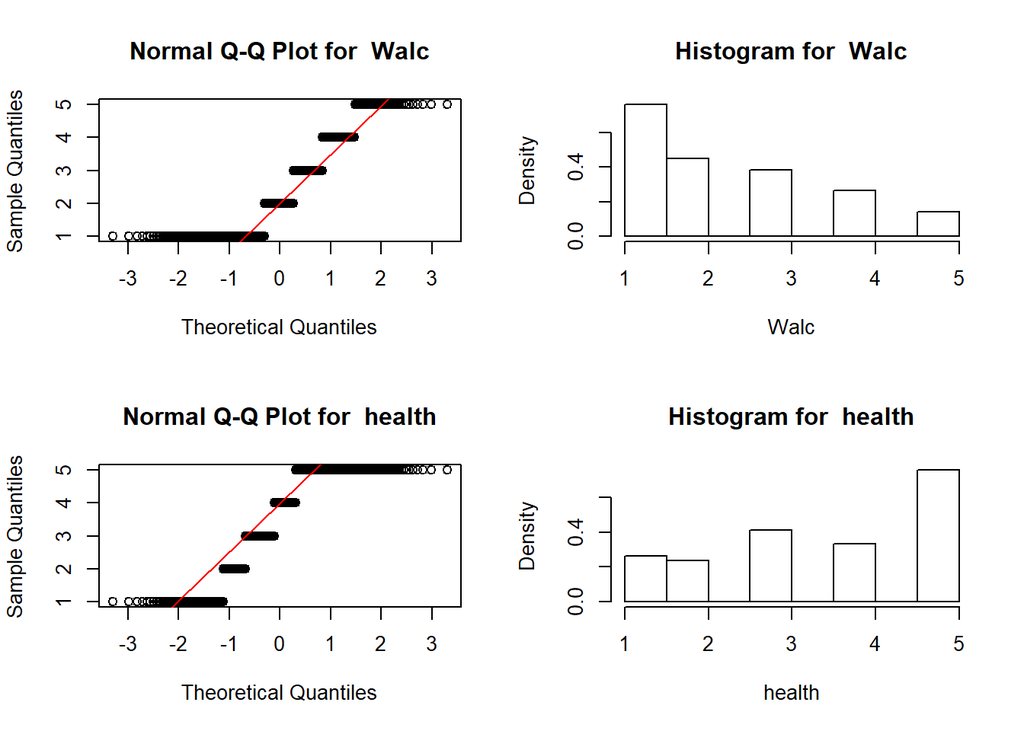

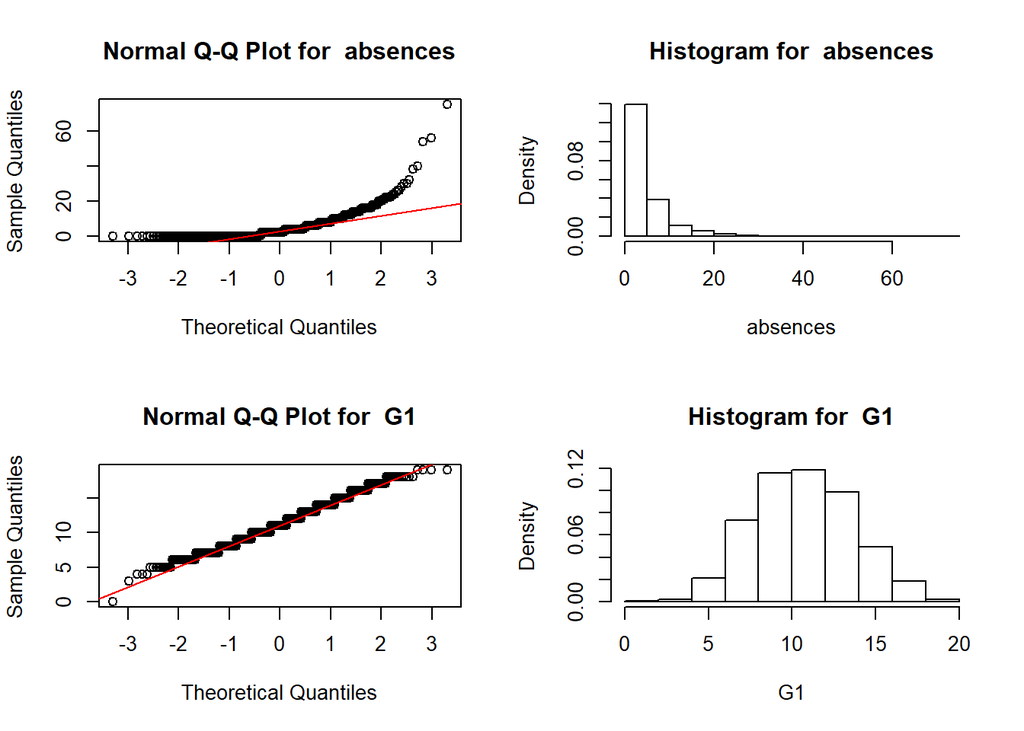

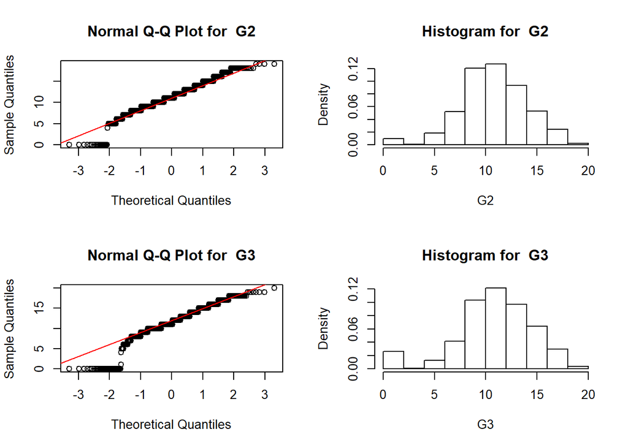

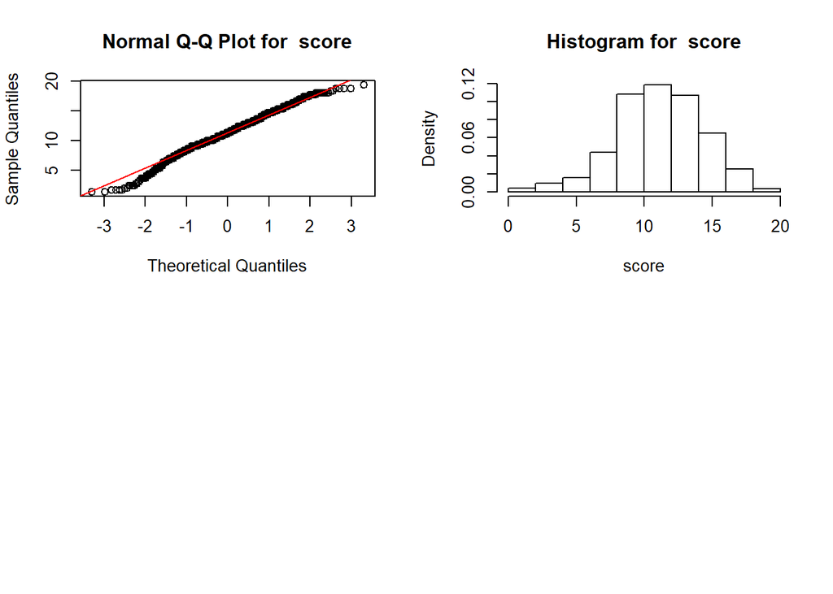

```r
plotNormHistogram <- function(data, name) {
    qqnorm(data,main = paste("Normal Q-Q Plot for ",name))
    qqline(data,col="red")
    hist(data,
      main=paste("Histogram for ", name),
      xlab=name, freq = FALSE)
}

par(mfrow=c(2,2))
for(i in 1:ncol(students)) {
  if (is.numeric(students[,i])){
    plotNormHistogram(students[,i], colnames(students)[i])
  }
}
```

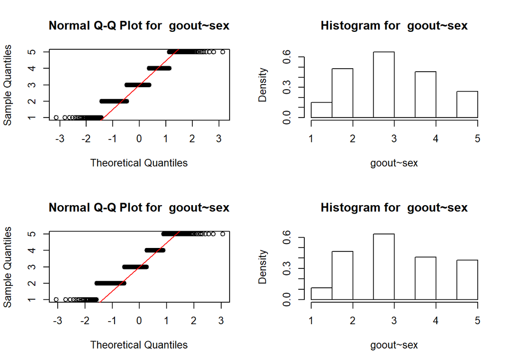

```r
par(mfrow=c(2,2))
plotNormHistogram(students[(students$sex == "F"),c("goout")], "goout~sex")
plotNormHistogram(students[(students$sex == "M"),c("goout")], "goout~sex")
```

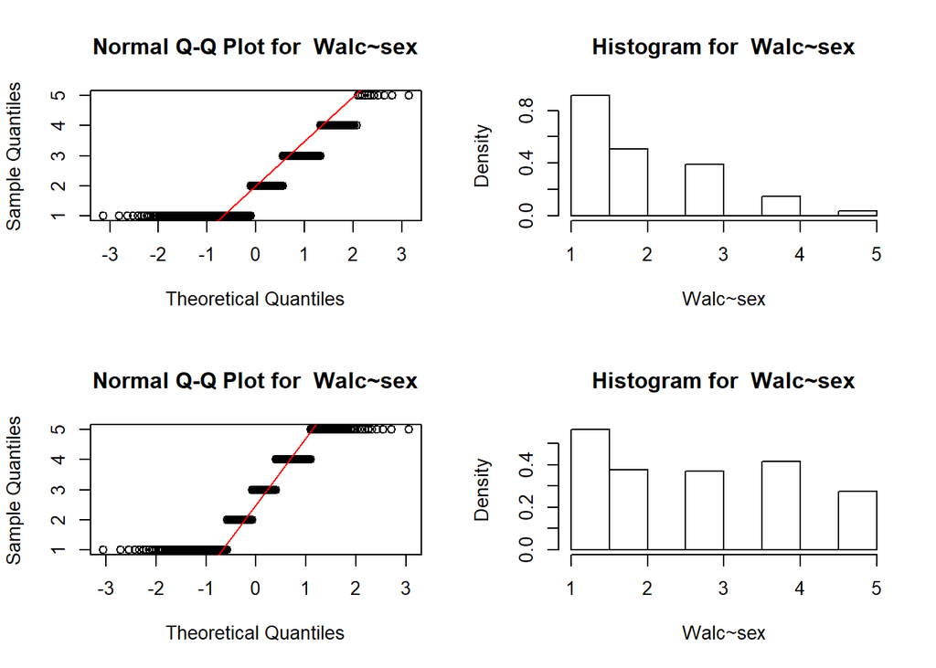

```r
plotNormHistogram(students[(students$sex == "F"),c("Walc")], "Walc~sex")
plotNormHistogram(students[(students$sex == "M"),c("Walc")], "Walc~sex")
```

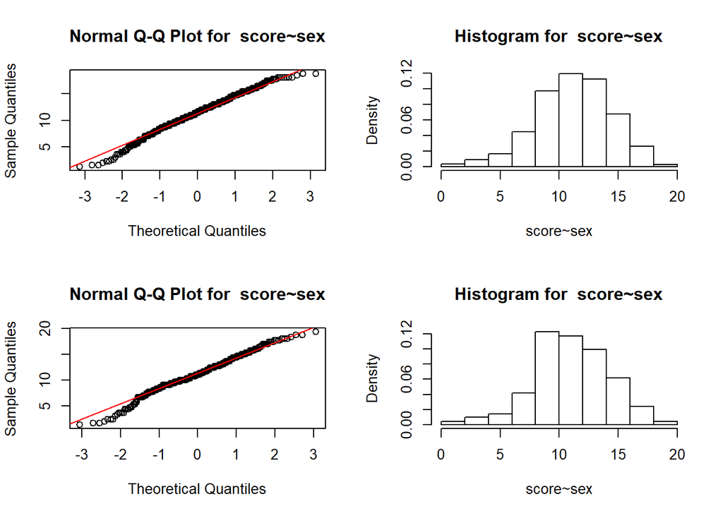

```r
plotNormHistogram(students[(students$sex == "F"),c("score")], "score~sex")
plotNormHistogram(students[(students$sex == "M"),c("score")], "score~sex")
```

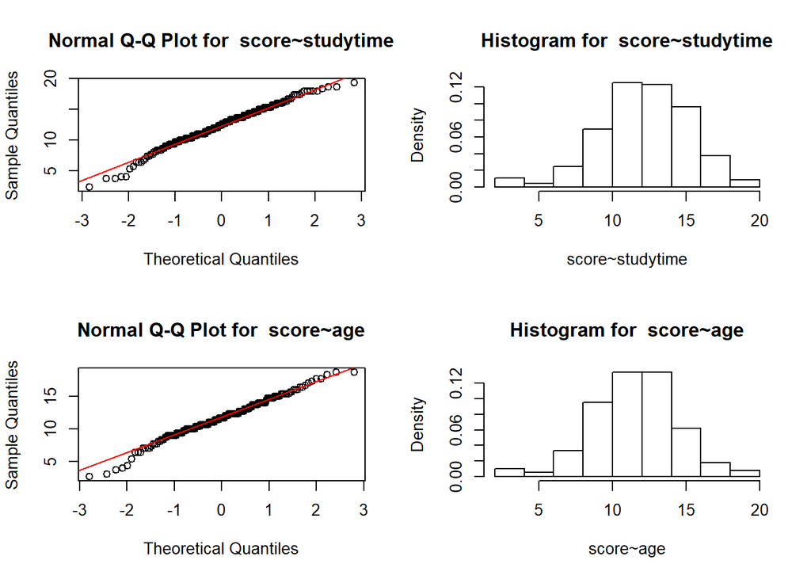

```r
plotNormHistogram(students[(students$studytime > 2),c("score")], "score~studytime")
plotNormHistogram(students[(students$age < 16),c("score")], "score~age")
```

## 1.6 Pruebas estadísticas

Aplicación de pruebas estadísticas para comparar los grupos de datos. En función de los datos y el objetivo del estudio, aplicar pruebas de contraste de hipótesis, correlaciones, regresiones, etc. Aplicar al menos tres métodos de análisis diferentes.

### 1.6.1 Correlaciones

```r
# Análisis de correlación
corr_matrix <- matrix(nc = 2, nr = 0)
colnames(corr_matrix) <- c("estimate", "p-value")
# Calcular el coeficiente de correlación para cada variable cuantitativa
# con respecto al campo "precio"
for (i in 1:(ncol(students))) {
  if (colnames(students)[i] != "score") {
    if (is.integer(students[,i]) | is.numeric(students[,i])) {
      spearman_test = cor.test(students[,i],
                              students$score,
                              method = "spearman")
      corr_coef = spearman_test$estimate
      p_val = spearman_test$p.value

      # Add row to matrix
      pair = matrix(ncol = 2, nrow = 1)
      pair[1][1] = corr_coef
      pair[2][1] = p_val
      corr_matrix <- rbind(corr_matrix, pair)
      rownames(corr_matrix)[nrow(corr_matrix)] <- colnames(students)[i]
    }
  }
}
print(corr_matrix)
```

```
##               estimate      p-value
## age        -0.12285038 6.898902e-05
## Medu        0.24518910 9.298302e-16
## Fedu        0.20340201 3.273473e-11
## traveltime -0.12895585 2.925874e-05
## studytime   0.20004048 6.947297e-11
## failures   -0.41737795 2.890952e-45
## famrel      0.03959414 2.011456e-01
## freetime   -0.07551607 1.466446e-02
## goout      -0.11679110 1.555327e-04
## Dalc       -0.16924285 3.763900e-08
## Walc       -0.14355324 3.209590e-06
## health     -0.07083599 2.208430e-02
## absences   -0.10393033 7.705005e-04
## G1          0.95083179 0.000000e+00
## G2          0.97620215 0.000000e+00
## G3          0.97637729 0.000000e+00
```

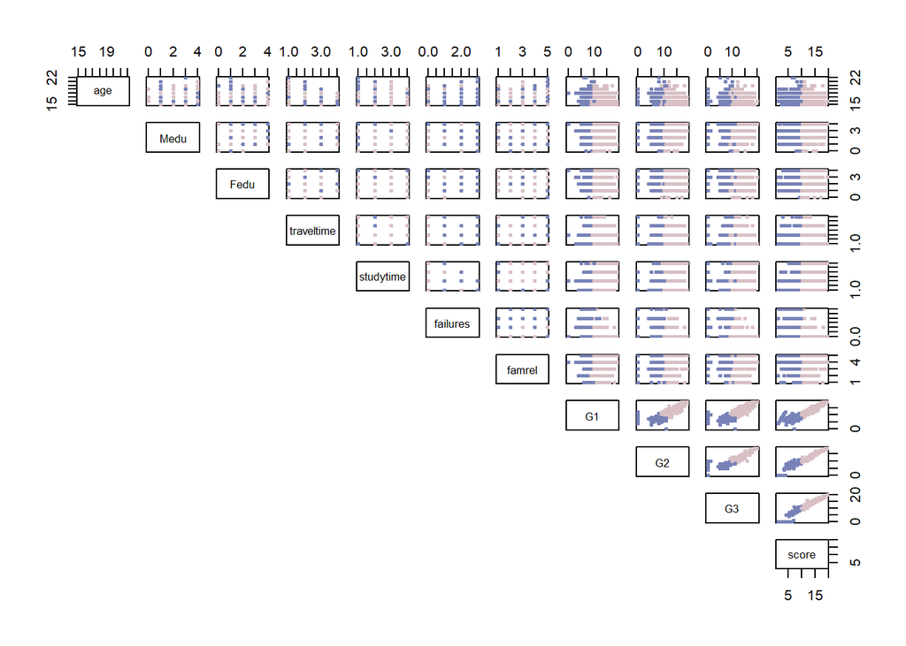

```r
color=diverge_hcl(length(students$mark))[rank(students$mark)]
pairs(~ age + Medu + Fedu + traveltime + studytime + failures + famrel + G1 + G2 + G3 + score, data = students, pch = 19, cex = 0.5, lower.panel = NULL, col = color)
```

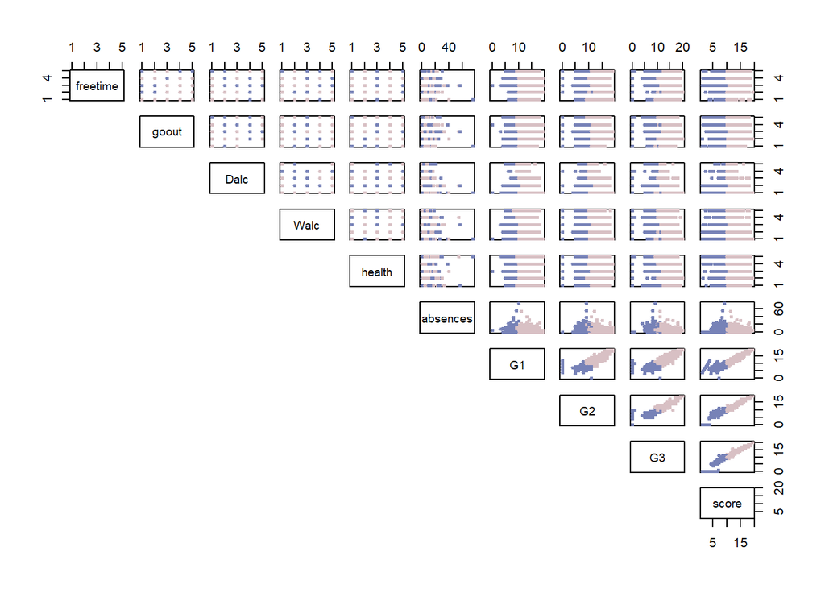

```r
pairs(~ freetime + goout + Dalc + Walc + health + absences + G1 + G2 + G3 + score, data = students, pch = 19, cex = 0.5, lower.panel = NULL, col = color)
```

### 1.6.2 ¿Las chicas sacan mejores notas que los chicos?

```r
t.test(students.male$score, students.female$score, alternative = "less")
```

```
##
##  Welch Two Sample t-test
##
## data:  students.male$score and students.female$score
## t = -0.93229, df = 972.51, p-value = 0.1757
## alternative hypothesis: true difference in means is less than 0
## 95 percent confidence interval:
##       -Inf 0.1435574
## sample estimates:
## mean of x mean of y
##  11.16115  11.34856
```

### 1.6.3 ¿Quien más tiempo dedica al estudio saca mejores notas?

```r
t.test(students.nostudytime$score, students.studytime$score, alternative = "less")
```

```
##
##  Welch Two Sample t-test
##
## data:  students.nostudytime$score and students.studytime$score
## t = -5.8354, df = 361.6, p-value = 5.964e-09
## alternative hypothesis: true difference in means is less than 0
## 95 percent confidence interval:
##        -Inf -0.9859761
## sample estimates:
## mean of x mean of y
##  10.97236  12.34673
```

### 1.6.4 Modelo lineal

```r
smp_siz = floor(0.75*nrow(students))

set.seed(123)   # set seed to ensure you always have same random numbers generated
train_ind = sample(seq_len(nrow(students)),size = smp_siz)  # Randomly identifies the rows equal to sample size ( defined in previous instruction) from  all the rows of Smarket dataset and stores the row number in train_ind
train = students[train_ind,] #creates the training dataset with row numbers stored in train_ind
test = students[-train_ind,]  # creates the test dataset excluding the row numbers mentioned in train_ind
```

```r
# Generación de varios modelos
modelo1 <- lm(score ~ G1, data = train)
modelo2 <- lm(score ~ G1 + G2, data = train)
modelo3 <- lm(score ~ G1 + G2 + G3, data = train)
modelo4 <- lm(score ~ G1 + G3, data = train)
modelo5 <- lm(score ~ G1 + G3 + studytime, data = train)
modelo6 <- lm(score ~ studytime + sex + absences, data = train)
modelo7 <- lm(score ~ studytime + paid, data = train)
modelo8 <- lm(score ~ G1 + G3 + studytime + paid, data = train)

tabla.coeficientes <- matrix(
    c(1, summary(modelo1)$r.squared,
      2, summary(modelo2)$r.squared,
      3, summary(modelo3)$r.squared,
      4, summary(modelo4)$r.squared,
      5, summary(modelo5)$r.squared,
      6, summary(modelo6)$r.squared,
      7, summary(modelo7)$r.squared,
      8, summary(modelo8)$r.squared),
    ncol = 2, byrow = TRUE)
colnames(tabla.coeficientes) <- c("Modelo", "R^2")
tabla.coeficientes
```

```
##      Modelo        R^2
## [1,]      1 0.85213764
## [2,]      2 0.97557027
## [3,]      3 1.00000000
## [4,]      4 0.98579767
## [5,]      5 0.98580377
## [6,]      6 0.03740947
## [7,]      7 0.03915323
## [8,]      8 0.98588380
```

```r
summary(modelo1)
```

```
##
## Call:
## lm(formula = score ~ G1, data = train)
##
## Residuals:
##     Min      1Q  Median      3Q     Max
## -8.0202 -0.3733 -0.0083  0.6564  7.3608
##
## Coefficients:
##             Estimate Std. Error t value Pr(>|t|)
## (Intercept) -0.02746    0.17378  -0.158    0.875
## G1           1.00397    0.01496  67.089   <2e-16 ***
## ---
## Signif. codes:  0 '***' 0.001 '**' 0.01 '*' 0.05 '.' 0.1 ' ' 1
##
## Residual standard error: 1.269 on 781 degrees of freedom
## Multiple R-squared:  0.8521, Adjusted R-squared:  0.8519
## F-statistic:  4501 on 1 and 781 DF,  p-value: < 2.2e-16
```

```r
y_predict = predict(modelo8, test)
```

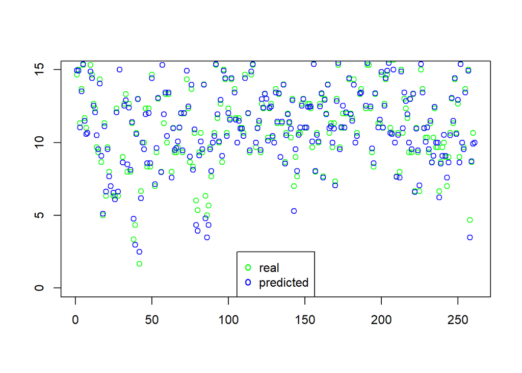

```
##   xchar= 7.313 ; (yextra,ychar)= 0 1.025
##   rect2(105.6,2.476, w=50.78, h=3.076, ...)
##   points2( 112.9 112.9 , 1.451 0.4253 , pch= o o , ...)
```

```r
plot(test$score, col = "green", xlab = "", ylab = "", ylim = range(0,15))
points(y_predict, col = "blue")
legend("bottom", c("real", "predicted"), pch = "o", col = c("green", "blue"), trace = TRUE)
```

# 2 Recursos

Los siguientes recursos son de utilidad para la realización de la práctica: ● Calvo M., Subirats L., Pérez D. (2019). Introducción a la limpieza y análisis de los datos. Editorial UOC. ● Megan Squire (2015). Clean Data. Packt Publishing Ltd. ● Jiawei Han, Micheine Kamber, Jian Pei (2012). Data mining: concepts and techniques. Morgan Kaufmann. ● Jason W. Osborne (2010). Data Cleaning Basics: Best Practices in Dealing with Extreme Scores. Newborn and Infant Nursing Reviews; 10 (1): pp. 1527-3369. ● Peter Dalgaard (2008). Introductory statistics with R. Springer Science & Business Media. ● Wes McKinney (2012). Python for Data Analysis. O’Reilley Media, Inc. ● Tutorial de Github https://guides.github.com/activities/hello-world.